# Coursework Report

*N* removed NAs: 2

*N* removed typo: 1

*N* removed <18: 38

*N* total clean: 109

| Group | *N* | *M*<sub>age</sub> | *M*<sub>rating</sub> |
| --- | --- | --- | --- |
| Control | 58 | 20.91 | 7.30 |
| Experim | 51 | 20.84 | 6.03 |

**Main analysis results**

*t*(107) = 9.71, *p* < .001

[interactive chart not shown]

[figure not shown]

[interactive chart not shown]

# Coursework Report

Analysing Data, Spring 2020

# Methods

## Participants

Table 1 *A Summary of Participants by Experimental Condition*

| Condition | N | *M*<sub>age</sub> | *SD*<sub>age</sub> |
| --- | --- | --- | --- |
| control | 58 | 20.91 | 2.04 |
| experimental | 51 | 20.84 | 2.25 |

## Design

The study investigated the conceptual hypothesis “Does colour influence attractiveness?”. In each condition, participants were informed that the experiment was based on first impressions of others. In each condition, participants saw one of two black-and-white photo of a “moderately attractive man” against a background; a white background (control condition) or a red bacground (experimental condition), for 5 seconds and then had to give their responses on the males’ perceived attracriveness. Perceived attractiveness was assessed with three face-valid questions: “How attractive do you think this person is?”,“How pleasant is this person to look at?” and lastly “If I were to meet the person in this picture face to face, I would think he is attractive.” Attractiveness was measured using a 9-point scale ranging from 1 (not at all attractive) and 9 (extremnely attractive). Colour is a measure using the two levels of the independant variable: white and red backgrounds, whilst attractiveness is a rating created using a range of scores from 1 to 9 where a higher score suggests greater attractiveness. Therefore, if a condition has higher attractiveness scores, this would be attributed to the manipulation of the photo background. The operational hypothesis of the study is “Does viewing a different colour background of the image of a moderately attractive male influence the mean ratings of his attractiveness?” This will be tested using the t-test statistic.

# Results

The overall pattern of the data suggests that participants rated the male as more attractive in the white condition (*M* = 7.3) than those in the red condition (*M* = 6.03) This means that on average, the participants found the male with the white background more attractive, due to higher ratings, in comparison to the red background.

A composite score was calculated by taking the mean of each participant’s scores on the three face-valid questions (How attractive do you think this person is?“,”How pleasant is this person to look at?" and lastly “If I were to meet the person in this picture face to face, I would think he is attractive.”) Participants had to respond on a scale rating of 1 to 9. Composite scores allow us to pin all the ratings together as shown in the graph below.

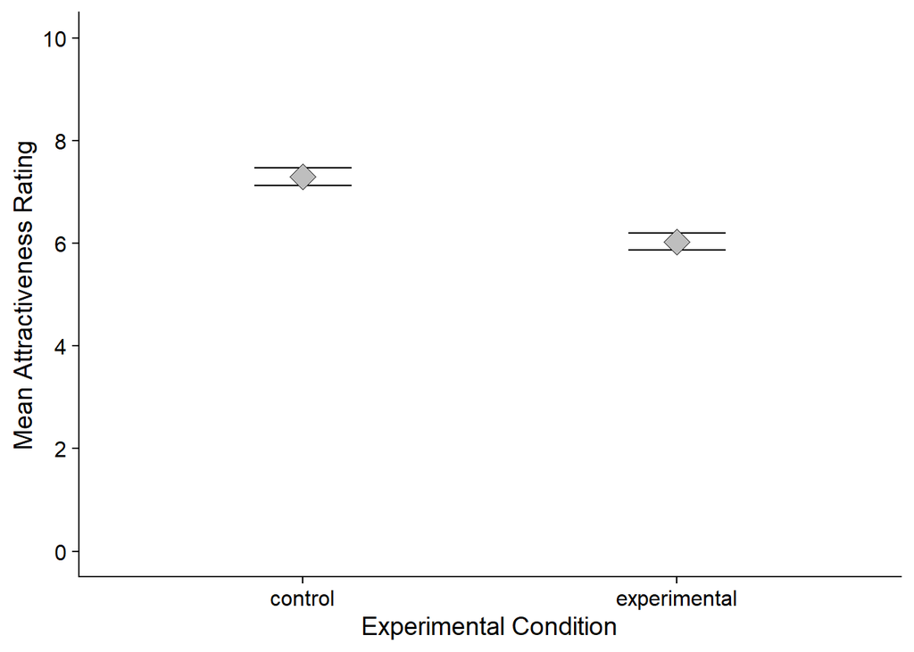

Figure 1. Mean plot of Composite Scores by Experimental Condition.

# Discussion

The findings of this replication do not support the conclusions of other studies in the same research field. For instance, (Elliot & Niesta, 2008) found that a black-and-white photograph of a woman in front of a red background was considered more attractive and sexually appealing by men, and participants wanted to engage with the woman in more sexual activity than the same woman in front of a white, grey or green background. This is further supported by research conducted on animals. Red is often an indicator for nonhuman animals, e.g. in stickleback fish where colour changes occur in males during mating to indicatechanges in reproductive status, superiority and individual efficiency, such as being able to provide vital resources (Hiermes et al., 2016). Research in this field investigated female three-spine sticklebacks under laboratory conditions showing bias for male stickleback fish that is more strongly red-coloured. During the process of egg selection, this female choice was observed in a natural habitat. It was found that “the more intense a male’s red breeding colouration, the more eggs he received.” This suggests that the colour red plays an important role in this attraction (Bakker & Mundwiler, 1994). This has also been found when red was displayed artificially. (Elliot et al., 2010).

However, a major weakness of using non-human species is that the study lacks generalisability to the human population. Studies using animals often do not account for the ecological setting as well as the evolutionary history of animals (Balda et al., 1998). Hence, as humans vary qualitatively from other species, extrapolation from animals to humans becomes an issue. This means that, this animal research offers little insight into human behaviour.

Additionally, this difference in results could also perhaps be due to the study design. Most studies investigating the effects of colour on attractiveness ratings manipulated the target’s clothing colour. For instance, Elliot and Niesta (2008: Study 5) found that a stimulus woman dressed in a red shirt earned higher ratings on perceived attractiveness, personal attraction, sexual desire, and likelihood to date and spend money on the woman as opposed to the same woman dressed in a blue shirt. This could perhaps be due to the fact that women in red clothes may feel more attractive and thus behave differently from women in other colours, emphasising the importance of separating perceiver from wearer effects when exploring the red effect (Peperkoorn et al., 2016). This could therefore question the validity of these studies as it suggests concerns with the design of the study. In future replications of the original study (Elliot et al., 2010), participants could be asked to rate the male’s attractiveness in different types of clothing whilst simultaneously manipulation the background colour.

Moreover, one strength of this research is that due to the standardised procedure, the study is easily susceptible to replications and therefore many results can be found to approve or disapprove the research question. These standardised procedures included showing a picture of a moderately attractive Caucasian male (4-in x 6-in head and upper torso shot) centred on 8.5-in x 11-in page with the background being either white (control condition) or red (experimental condition). Perceived attractiveness was assessed on a 9-point scale ranging from 1 to 9 on three items. The basic elements of this standardised procedure were often replicated when researching the influence of colour on attractiveness ratings. For instance, Peperkoorn et al., 2016, followed a similar procedure of the participants being told that the experiment concerned first impressions of other people as well as using a background colour against a cropped image and assessing the attractiveness rating on a 9-point scale. Despite this study not supporting the results as found in the original study, the fact that the study was standardised it makes it more practical. Due to this procedure being replicable, it also increases repeatability and so the research questions can be thoroughly investigated.

Despite past research investigating the effects of the colour red, it still has various limitations. One such discrepancy is the relative lack of scientific insight into the impact of red on adolescents viewed by others as attractive, with research mostly focused on non-human primates, men or women after age 20 (Williams et al., 2017). Additionally, in the original study, it specifically used young Caucasian males (Elliot et al., 2010). However, research on adolescents could have positive implications for future research. For example, the effect of physical appearance on the first impressions of peers of young adults has been explored by previous studies. Unattractive children were found to be significantly less popular than attractive children, with the exception of younger females. Therefore, if red would make males appear more attractive to their opposite gender peers, it might potentially help them make different choices like in their clothes (Dion & Berscheid, 1974). Furthermore, using a specific group of people could raise issues of individual differences as some may just have a preference in contrast to the colour playing a role. As seen in the study conducted by Young, 2015, 40 images were used to investigate “The effects of red on male perceptions of female attractiveness: moderation by baseline attractiveness of female faces”. Results show that red affected females’ attractiveness (increasing their perceived attractiveness) and yet when pre-rated as attractive this did not have any impact on when pre-rated as unattractive. This is important as baseline attractiveness could have acted as a confounding variable. Thus, to improve the original study, future research should take into account baseline of attractiveness being determined to produce valid results (Young, 2015).

To conclude, the replication study suggested that a white background had more of an effect as its increased ratings of attractiveness of the male in comparison to the red background. However, it is important to note that implications of this study suggest that the red effect is significant and therefore we can’t come to a full conclusion on the red effect having no effect on attractiveness ratings. Future research should be focused on areas that are lacking such as influence of clothing, using non-human species, using a specific group of people and setting a baseline of attractiveness.

# References

Bakker, T. C. M., & Mundwiler, B. (1994). Female mate choice and male red coloration in a natural three-spined stickleback (Gasterosteus aculeatus) population. Behavioral Ecology, 5(1), 74–80. https://doi.org/10.1093/beheco/5.1.74

Balda, R. P., Pepperberg, I. M., & Kamil, A. C. (1998). Animal Cognition in Nature: The Convergence of Psychology and Biology in Laboratory and Field. Academic Press.

Dion, K. K., & Berscheid, E. (1974). Physical Attractiveness and Peer Perception Among Children. Sociometry, 37(1), 1–12. JSTOR. https://doi.org/10.2307/2786463

Elliot, A. J., & Niesta, D. (2008). Romantic red: Red enhances men’s attraction to women. Journal of Personality and Social Psychology, 95(5), 1150–1164. https://doi.org/10.1037/0022-3514.95.5.1150

Elliot, A. J., Niesta Kayser, D., Greitemeyer, T., Lichtenfeld, S., Gramzow, R. H., Maier, M. A., & Liu, H. (2010). Red, rank, and romance in women viewing men. Journal of Experimental Psychology: General, 139(3), 399–417. https://doi.org/10.1037/a0019689

Hiermes, M., Rick, I. P., Mehlis, M., & Bakker, T. C. M. (2016). The dynamics of color signals in male threespine sticklebacks Gasterosteus aculeatus. Current Zoology, 62(1), 23–31. https://doi.org/10.1093/cz/zov009

Peperkoorn, L. S., Roberts, S. C., & Pollet, T. V. (2016). Revisiting the Red Effect on Attractiveness and Sexual Receptivity: No Effect of the Color Red on Human Mate Preferences. Evolutionary Psychology, 14(4), 147470491667384. https://doi.org/10.1177/1474704916673841

Williams, L., Schofield, T., & Whitford, T. (2017). Romantic Red: Testing the Characteristics of Color–Attraction Effects in a Novel Paradigm. Collabra: Psychology, 3, 10. https://doi.org/10.1525/collabra.54

Young, S. G. (2015). The effect of red on male perceptions of female attractiveness: Moderation by baseline attractiveness of female faces. European Journal of Social Psychology, 45(2), 146–151. https://doi.org/10.1002/ejsp.2098